# Homework 15: Multivariant Aalysis with PCA and NMDS

# 3 Capsul PCA and NMDS

Perform a principal coordinates analysis (with capscale), and compare the ordination to the NMDS ordination using procrustes(). Do the two methods give similar results? How much variation in community composition is explained by the first few PCoA axes? Using the subset of environmental variables you chose earlier, use envfit() to see how the environmental variables relate to the NMDS ordination axes. Plot the results. Which variables seem most strongly related to the major axes of community variation?

**Answer:** By comparing the two figures in the PCoA vs NMDS tab, it appears that the analyses are relatively dis-similar. But it is difficult to choose which version is better. 49% of the variation is explained by the first few axes of the PCoA analysis. Sand and then pH seem most strongly related to the major axes of community variation, shown in the “Plotting NMDS and Env” tab.

## 3.1 PCoA

```r
pcoa = vegan::capscale(species ~ 1, dist = "bray")
#pcoa
test <- summary(pcoa)
test <- test$cont
test <- data.frame(test)[,1:6]
sum(test[2,])
```

```
## [1] 0.493603
```

```r
data.frame(test)[,1:6]
```

```
##                       importance.MDS1 importance.MDS2 importance.MDS3
## Eigenvalue                  3.0950330      1.47659205      1.23587191
## Proportion Explained        0.1742352      0.08312491      0.06957354
## Cumulative Proportion       0.1742352      0.25736012      0.32693366
##                       importance.MDS4 importance.MDS5 importance.MDS6
## Eigenvalue                 1.00944584       1.0026182      0.94857171
## Proportion Explained       0.05682686       0.0564425      0.05339994
## Cumulative Proportion      0.38376052       0.4402030      0.49360296
```

## 3.2 PCoA vs NMDS

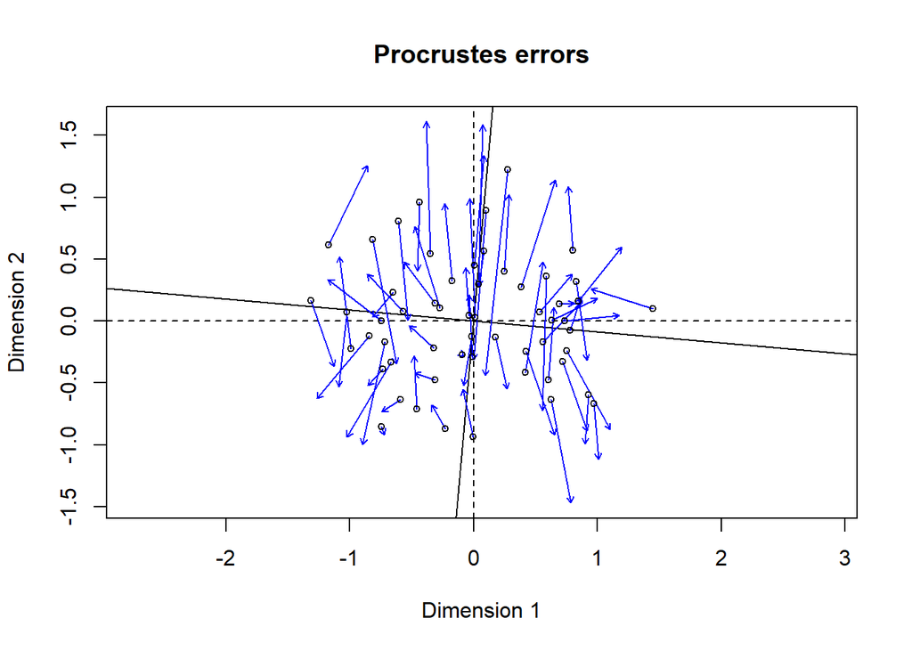

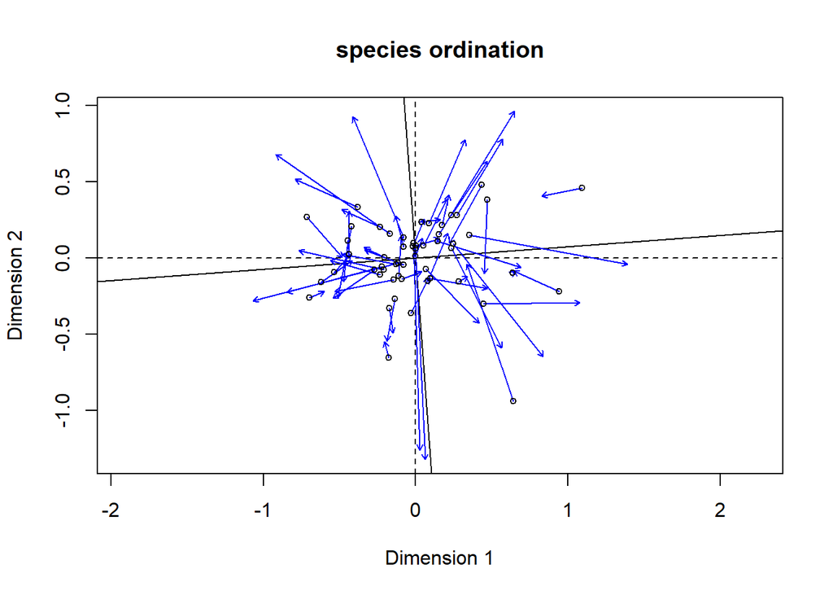

```r
proc = vegan::procrustes(pcoa, ord)
plot(proc)

proc = vegan::procrustes(ord$species, summary(pcoa)$species[,1:2])
plot(proc, main = 'species ordination')
```

## 3.3 NMDS and the Environment

```r
names(env)[1] <- "t"
fit = vegan::envfit(ord ~ t + pH + oxygen + PO4 + Turb + Sand, data = env, na.rm = TRUE)
fit
```

```
##
## ***VECTORS
##
##           NMDS1    NMDS2     r2 Pr(>r)
## t       0.96245  0.27146 0.0656  0.160
## pH      0.77265  0.63483 0.1355  0.016 *
## oxygen -0.52664  0.85009 0.0592  0.193
## PO4     0.08875 -0.99605 0.0051  0.880
## Turb   -0.65737 -0.75357 0.0301  0.432
## Sand   -0.86717 -0.49801 0.2393  0.003 **
## ---
## Signif. codes:  0 '***' 0.001 '**' 0.01 '*' 0.05 '.' 0.1 ' ' 1
## Permutation: free
## Number of permutations: 999
```

## 3.4 Plotting NMDS and Env

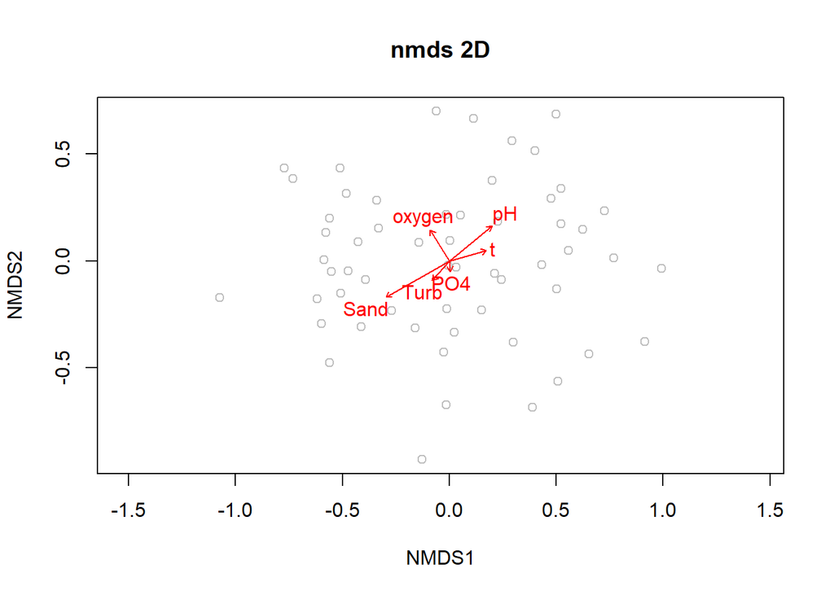

```r
vegan::ordiplot(ord, display = "sites", type = 'n', main = 'nmds 2D')
points(ord, col = 'grey')
plot(fit, col = 'red', arrow.mul = 0.7)
```

# 4 Constrained Ordination: PCoA

Now use constrained ordination (canonical analysis of principal coordinates) to more directly look for axes of community variation that are explained by the environment. Plot the site scores and the biplot arrows for the environmental axes. How are the environmental variables aligned along the most important axes? How much variation in community composition is explained by those axes? Test whether the axes are ‘significant’, using the permutation tests provided by the anova() function. Use a plot of the species scores, in combination with the environmental vectors, to see which invertebrate families respond most strongly to the different environmental axes.

# 5 CAP Summary and anova

```r
cap = vegan::capscale(species ~ t + pH + oxygen + PO4 + Turb + Sand, data = env, dist = "bray")
#summary(cap)$cont
#summary(cap)$biplot
cap
```

```
## Call: vegan::capscale(formula = species ~ t + pH + oxygen + PO4 + Turb
## + Sand, data = env, distance = "bray")
##
##                Inertia Proportion Rank
## Total         16.51644    1.00000
## Constrained    3.02265    0.18301    6
## Unconstrained 14.74088    0.89250   38
## Imaginary     -1.24709   -0.07551   18
## Inertia is squared Bray distance
## Species scores projected from 'species'
##
## Eigenvalues for constrained axes:
##   CAP1   CAP2   CAP3   CAP4   CAP5   CAP6
## 1.5563 0.4895 0.3388 0.2827 0.1928 0.1625
##
## Eigenvalues for unconstrained axes:
##   MDS1   MDS2   MDS3   MDS4   MDS5   MDS6   MDS7   MDS8
## 1.9388 1.3247 1.0737 0.9758 0.8878 0.8347 0.7481 0.6668
## (Showing 8 of 38 unconstrained eigenvalues)
```

```r
anova(cap)
```

```
## Permutation test for capscale under reduced model
## Permutation: free
## Number of permutations: 999
##
## Model: vegan::capscale(formula = species ~ t + pH + oxygen + PO4 + Turb + Sand, data = env, distance = "bray")
##          Df SumOfSqs      F Pr(>F)
## Model     6   3.0226 1.7088  0.001 ***
## Residual 50  14.7409
## ---
## Signif. codes:  0 '***' 0.001 '**' 0.01 '*' 0.05 '.' 0.1 ' ' 1
```

```r
anova(cap, by = "axis")
```

```
## Permutation test for capscale under reduced model
## Forward tests for axes
## Permutation: free
## Number of permutations: 999
##
## Model: vegan::capscale(formula = species ~ t + pH + oxygen + PO4 + Turb + Sand, data = env, distance = "bray")
##          Df SumOfSqs      F Pr(>F)
## CAP1      1   1.5563 5.2790  0.001 ***
## CAP2      1   0.4895 1.6605  0.468
## CAP3      1   0.3388 1.1492  0.936
## CAP4      1   0.2827 0.9589  0.961
## CAP5      1   0.1928 0.6539  0.994
## CAP6      1   0.1625 0.5512  0.976
## Residual 50  14.7409
## ---
## Signif. codes:  0 '***' 0.001 '**' 0.01 '*' 0.05 '.' 0.1 ' ' 1
```

```r
anova(cap, by = "margin")
```

```
## Permutation test for capscale under reduced model
## Marginal effects of terms
## Permutation: free
## Number of permutations: 999
##
## Model: vegan::capscale(formula = species ~ t + pH + oxygen + PO4 + Turb + Sand, data = env, distance = "bray")
##          Df SumOfSqs      F Pr(>F)
## t         1   0.3999 1.3563  0.123
## pH        1   0.3333 1.1305  0.288
## oxygen    1   0.4262 1.4455  0.108
## PO4       1   0.2967 1.0063  0.412
## Turb      1   0.3419 1.1597  0.255
## Sand      1   0.9680 3.2834  0.001 ***
## Residual 50  14.7409
## ---
## Signif. codes:  0 '***' 0.001 '**' 0.01 '*' 0.05 '.' 0.1 ' ' 1
```

## 5.1 Plotting site and species scores

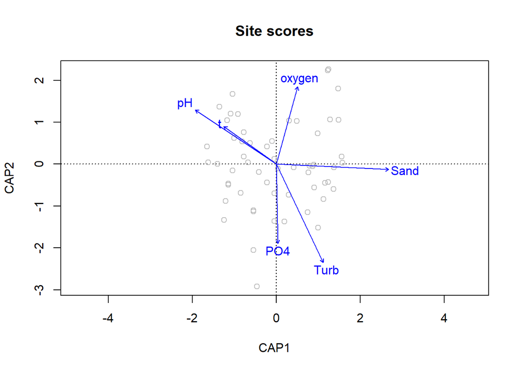

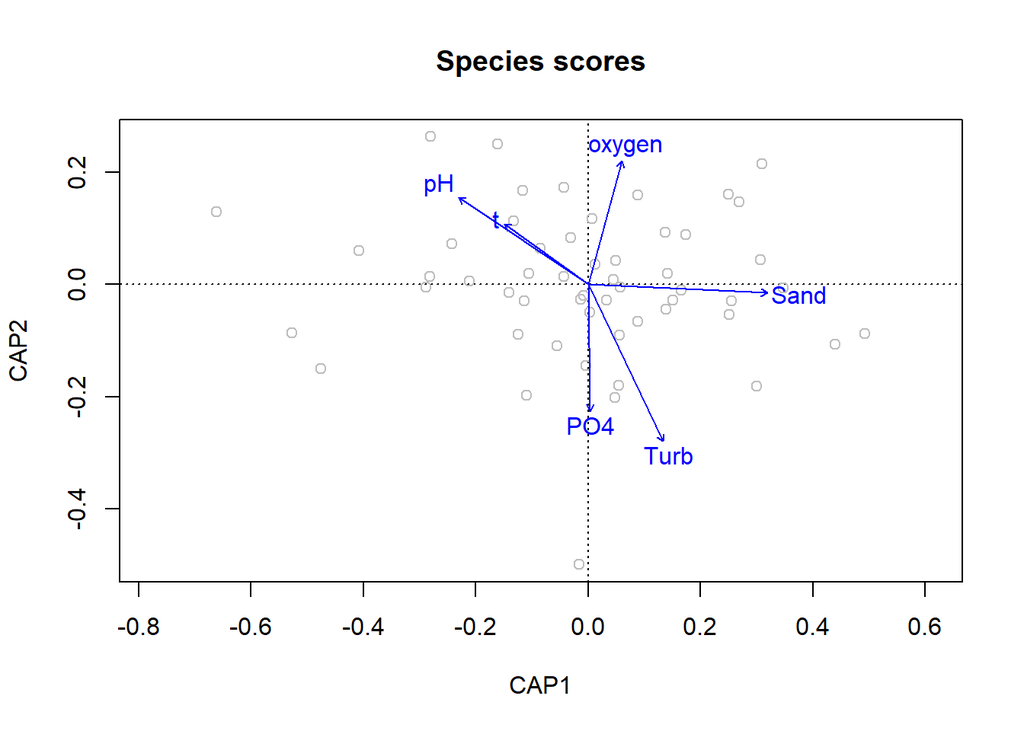

```r
plot(cap, display = "sites", type = 'n', main = "Site scores")
points(cap, display = "sites", col = 'grey')
text(cap, display = 'bp', col = 'blue')


plot(cap, display = "species", type = 'n', main = "Species scores")
points(cap, display = "species", col = 'grey')
text(cap, display = 'bp', col = 'blue')
```

# 6 PERMANOVA

You’ve been looking at overall variation in community composition, but the authors of the study were most interested in the effects of salinity and pesticides. Use permanova (i.e., adonis()) to test the effect of these predictors on community composition. Are there significant effects? How much variation is explained? Is there an interaction between the two predictors? Would you consider these to be strong environmental impacts, at least in terms of changing the structure of the stream invertebrate communities

## 6.1 Re-processing data

```r
invert <- read.csv(paste(infile, "macroinverts.csv", sep = ""))
invert = na.omit(invert)

# Seperating the site from the month
site  <- substr(invert$Site_Month, 1, 2)
month <- substr(invert$Site_Month, 3, 4)
invert$site  <- as.factor(gsub("[[:punct:]]", "", site))
invert$month <- as.numeric(gsub("[[:punct:]]", "", month))
rm(month)
invert <- invert[, 2:ncol(invert)]

env <- invert[, c("T","pH","Cond","oxygen", "PO4", "Turb", "Bedrock", "Boulder",
                  "Cobble","Pebble", "Gravel", "Sand", "Clay.silt")]
                  bady <- c("PO4", "Bedrock", "Boulder", "Cobble", "Pebble", "Gravel", "Sand")
env[, bady] <- sqrt(env[ , bady])
env[, "Cond"] <- log(env[, "Cond"])

drop   = c("Bedrock", "Boulder", "Cobble", "Pebble", "Gravel", "Clay.silt")
invert = invert[, !is.element(names(invert), drop)]
env    = env[, !is.element(names(env), drop)]
```

# 7 PERMANOVA

```r
mod_int   <- vegan::adonis2(species ~ PO4 * Cond , data = env, dist = 'bray', by = 'margin')
mod_noint <- vegan::adonis2(species ~ PO4 + Cond , data = env, dist = 'bray', by = 'margin')

mod_int
```

```
## Permutation test for adonis under reduced model
## Marginal effects of terms
## Permutation: free
## Number of permutations: 999
##
## vegan::adonis2(formula = species ~ PO4 * Cond, data = env, by = "margin", dist = "bray")
##          Df SumOfSqs      R2      F Pr(>F)
## PO4:Cond  1   0.4589 0.02779 1.6781  0.035 *
## Residual 53  14.4940 0.87755
## Total    56  16.5164 1.00000
## ---
## Signif. codes:  0 '***' 0.001 '**' 0.01 '*' 0.05 '.' 0.1 ' ' 1
```

```r
mod_noint
```

```
## Permutation test for adonis under reduced model
## Marginal effects of terms
## Permutation: free
## Number of permutations: 999
##
## vegan::adonis2(formula = species ~ PO4 + Cond, data = env, by = "margin", dist = "bray")
##          Df SumOfSqs      R2      F Pr(>F)
## PO4       1   0.3062 0.01854 1.1059  0.304
## Cond      1   1.2604 0.07631 4.5517  0.001 ***
## Residual 54  14.9529 0.90534
## Total    56  16.5164 1.00000
## ---
## Signif. codes:  0 '***' 0.001 '**' 0.01 '*' 0.05 '.' 0.1 ' ' 1
```